# jacobian

```python
import numpy as np
import scipy.stats as stats
import matplotlib.pyplot as plt
import seaborn as sns
```

```python
def hide_axes_for_density():
    ax = plt.gca()
    for name, spine in ax.spines.items():
        if name != "bottom":
            spine.set_visible(False)
```

## The Jacobian adjustment

Despite the fact that it is a pretty common tool in Bayesian modelling, I could not find something like a blog post explaining the concept of Jacobian adjustment in a way that I was happy with. [This blogpost](http://rstudio-pubs-static.s3.amazonaws.com/486816_440106f76c944734a7d4c84761e37388.html) is good but quite Stan-centric, so hard to understand for non-Stanners.

So here is my attempt to go through the idea in excessive details. The situation is the following. We know the distribution $f_X$ of some variable $X$. However, for some reason we are not interested in $X$, but rather in the distribution of a function $g$ of $X$, $Y$:

$$ X \sim f_X \\ Y = g(X) $$

The question is: what is the probability density $f_Y$ for variable $Y$? Take a moment to think about this problem. The answer is not obvious!

One first tempting answer would be: it's just the transformation of the density, i.e. $g\circ f_X$. That this cannot be the answer can already by seen by the fact that the resulting function would not be a probability density. Consider for example:

$$ g(x) = 2x \\ \int f_X(x) dx = 1 \implies \int g(f_X(x)) dx = 2 \int f_X(x) dx = 2 $$

Since the transformation of the density integrates to 2, it's not a density. Even conceptually, that answer would not make sense: the probability that $Y$ takes on value $y$ would be unrelated to the probability of point $y$ before the transformation, i.e. $f_X(g^{-1}(y))$. Intuitively, the two must be related (keep this in mind!).

So a second appealing answer would be: the probability that $X$ takes on any value $y$ is just the probability of $y$ in the original space, i.e. $f_X(g^{-1}(y))$. This is closer to the right answer, but still not quite right. Why not? Well, consider for example the case where $f_X$ is a standard normal distribution, and $g(x) = x^2$. Then what would be the measure of the transformed variable over the whole space? If it is a density, it should be 1:

$$ f_X(x) = \frac{1}{\sqrt{2\pi}} e^{-\frac{x^2}{2}} \\ \begin{align} f_Y(x) = & \int_{\mathbb{R}} \frac{1}{\sqrt{2\pi}} e^{-\frac{\sqrt{(x)}^2}{2}} dx \\ = & \frac{1}{\sqrt{2\pi}} \int_{\mathbb{R}} e^{-\frac{x}{2}} dx \\ = & - \frac{2}{\sqrt{2\pi}} \int_{\mathbb{R}} e^y dy \\ \end{align} $$

And since $\int_{\mathbb{R}} e^y dy$ is a divergent integral, this is definitely not equal to 1! So why is this answer wrong, intuitively? Well, the transformation is squeezing and stretching the original space in various ways, so if you pick any part of the space, the probability mass of that part of the space after the transformation might end up covering a huge part of the space. We have to compensate for this! This is exactly the purpose of the Jacobian adjustment.

I'm first going to show what the right answer looks like, and then explain. The following answers the original question:

$$ f_Y(x) = f_X(g^{-1}(x)) \left\lvert \mathbf{J}_{g^{-1}}(x) \right\rvert $$

Let's consider the two terms of the multiplication in turn. First, what is $f_X(g^{-1}(x))$? This is simply the probability of $g^{-1}(x)$ wrt the original distribution. Note that we can calculate this because we know the density $f_X$, what we don't know is $f_Y$! Again, the point $g^{-1}(x)$ is the point that the transformation $g$ brings to $x$. So the first term just tells us what the probability of $x$ was before the transformation.

The second term, $\lvert \mathbf{J}_{g^{-1}}(x) \rvert$, is called the Jacobian adjustment and is a little bit more complicated.

First of all, $\mathbf{J}_h$ is the *Jacobian matrix* of some transformation $h$, where $h$ is any function $h: \mathbb{R^n} \to \mathbb{R^m}$ such that all first-order partial derivatives exist. The Jacobian matrix is the matrix of partial derivatives of $h$:

$$ \begin{bmatrix} \frac{\partial g_1}{\partial x_1} & \dots & \frac{\partial g_1}{\partial x_n} \\ \vdots & & \vdots \\ \frac{\partial g_m}{\partial x_1} & \dots & \frac{\partial g_m}{\partial x_n} \\ \end{bmatrix} $$

The components of this matrix are therefore functions, which can be evaluated at a point. The matrix evaluated at a point $x$, is just the matrix consisting of all the partial derivatives evaluated at that point.

Here, I will only consider the simple case where $h: \mathbb{R} \to \mathbb{R}$. Therefore, the Jacobian matrix simply becomes the derivative:

$$ f_Y(x) = f_X(g^{-1}(x)) \left\lvert \frac{dg^{-1}}{dx}(x) \right\rvert $$

So what this allows us to do is to find the density of a transformed variable in terms of the density of the original variable.

Does the new strategy-multiplying by the Jacobian-result in a real probability density function? As it turns out, yes! Showing this is just an application of the change of variable technique from calculus:

$$ \int_a^b f(u) du = \int_{\phi^{-1}(a)}^{\phi^{-1}(b)} f\left( \phi(x) \right) \frac{d}{dx}\phi(x) dx $$

## Markov Chain Monte Carlo samplers!

MCMC is a class of algorithms to sample from a distribution that we can only calculate up to a normalization factor. The simplest MCMC algorithm is called the *Metropolis-Hastings* algorithm, and here is a super short version of it:

```python
def simple_metropolis_hasting(unnormalised_density, proposal_func, start, n_samples, burn_in=500):

    assert(burn_in < n_samples), "burn_in cannot be smaller than n_samples!"

    samples = np.empty(n_samples)
    state = start
    for sample_i in range(n_samples):
        f_state = unnormalised_density(state)

        proposal = proposal_func(state)
        f_proposal = unnormalised_density(proposal)

        acceptance_ratio = f_proposal / f_state
        if np.random.rand() < acceptance_ratio:
            state, f_state = proposal, f_proposal

        samples[sample_i] = state

    return samples[burn_in:]
```

To see how this works, suppose that we want to sample from an unnormalized normal distribution (`unnorm_density`):

```python
mu, var = 0, 1
# Note for readers: Do not use scipy stats functions. They are *super* slow and create bottlenecks.
unnorm_density = lambda x: np.exp( -(x - mu)**2 / (2 * var) )
```

We also need a *proposal function* and to decide the value of a couple other variables. The details are not important here:

```python
proposal_func = lambda mu: np.random.normal(loc=mu, scale=0.1)
samples = simple_metropolis_hasting(unnorm_density, proposal_func, -0.3, 1000000)
```

The important thing is that the samples we took are distributed like the normalized distribution, as can be seen by overlapping the distribution estimated from the samples with the actual distribution. *Super* close:

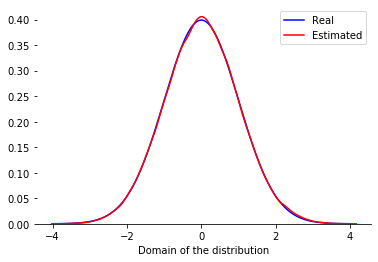

```python
xs = np.linspace(-4, 4, 1000)
ys = stats.norm.pdf(xs)
plt.plot(xs, ys, color="blue", label="Real")
sns.distplot(samples, color="red", label="Estimated", hist=False)
plt.xlabel("Domain of the distribution")
plt.legend()
hide_axes_for_density()
plt.show()
```

## Transform and then sample, or sample and then transform: your choice!

In this bit I want to clarify [a passage in the STAN manual](https://mc-stan.org/docs/2_18/stan-users-guide/changes-of-variables.html) that says:

> A transformation samples a parameter, then transform it, whereas a change of variables transforms a parameter, then samples it. Only the latter requires a Jacobian adjustment.

The first time I read this quote I was a bit puzzled. It's clear what it means to sample a parameter and then transform it. But what does it mean to transform a parameter, and then sample it? That's what we have done above with the Jacobian transformation: first you find the distribution of the transformed variable, then you sample from the distribution you found. I am going to work through a simple example to show that the two are indeed equivalent.

Assume that the known distribution of our untransformed variable is a standard normal distribution, and that the transformation we are interested in is the expit function, which maps $(-\infty, \infty) \to (0, 1)$:

$$ \frac{e^x}{1 + e^x} $$

Its inverse is the logit function:

$$ \log \left( \frac{x}{1-x} \right) $$

And the derivative of the inverse expit (i.e. the derivative of the logit) is:

$$ \frac{1}{x - x^2} $$

In code form:

```python
def expit(x):
    return np.exp(x) / (1 + np.exp(x))

def inverse_expit(x):
    return np.log(x / (1 - x))

def derivative_inverse_expit(x):
    return 1 / (x - np.square(x))
```

Given what was said above, the density of the expit-transformed variable at a point $x$:

$$ f_Y(x) = f_X \left( \log \left( \frac{x}{1-x} \right) \right) \frac{1}{x-x^2} $$

I cancelled the absolute value function because the derivative of the inverse logit, being a fraction of two functions that are non-negative everywhere, is also non-negative everywhere. This can also be seen from the following plot:

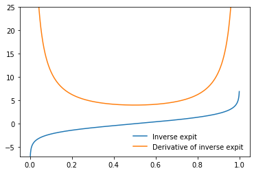

```python
xs = np.linspace(0.001, 0.999, 1000)
plt.plot(xs, inverse_expit(xs), label="Inverse expit")
plt.plot(xs, derivative_inverse_expit(xs), label="Derivative of inverse expit")
plt.ylim(-7, 25)
plt.legend(frameon=False)
plt.show()
```

Now, define the functions that return the density of the normal distribution at a point and the density for the transformation:

```python
def normal_density(x, mu=0, var=1):
    return 1/np.sqrt(2*np.pi*var) * np.exp(-np.square(mu-x)/(2*var))

def transformed_density(original_density):
    return lambda x: original_density(inverse_expit(x)) * derivative_inverse_expit(x)
```

Notice that the distribution is "squeezed" in the way we would expect, i.e. to the (0,1) interval. However, it is squeezed in an intelligent way that preserves the probability measure, thanks to the Jacobian adjustment:

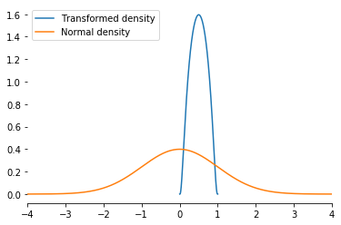

```python
xs = np.linspace(0.001, 0.999, 1000)
plt.plot(xs, transformed_density(normal_density)(xs), label="Transformed density")
xs = np.linspace(-4, 4, 1000)
plt.plot(xs, normal_density(xs), label="Normal density")
plt.legend()
hide_axes_for_density()
plt.xlim(-4,4)
plt.show()
```

Now, we can do two equivalent things to get samples from our transformed distribution.

1. Take samples directly from the transformed distribution that we calculated with the Jacobian adjustment.
2. First take samples from the untransformed distribution (the normal), and then transform the samples. This is in effect the way that we have been thinking about what we are doing all along: a transformation of a random variable.

Let's first take the samples from the transformed density:

```python
clipped_proposal_func = lambda x: np.random.rand()
samples_transformed = simple_metropolis_hasting(
    transformed_density(normal_density),
    clipped_proposal_func,
    0.1, 1000000
)
```

And then take the samples from the original density, to transform them later:

```python
samples_untransformed = simple_metropolis_hasting(
    normal_density,
    lambda mu: np.random.normal(loc=mu, scale=0.1),
    0.1, 1000000
)
```

Finally, compare the distributions estimated from the samples taken with the two strategies. They are *super* close:

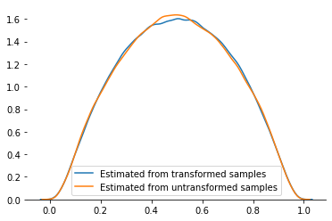

```python
sns.distplot(samples_transformed, hist=False, label="Estimated from transformed samples")
sns.distplot(expit(samples_untransformed), hist=False, label="Estimated from untransformed samples")
hide_axes_for_density()
plt.show()
```

## Concluding remarks

If you are working with log-probabilities (which you should always do), you can get the log-probability in the transformed space by *adding* the Jacobian adjustment, rather than multiplying by it. This is why in STAN the Jacobian ajudstment is added.

Hopefully this gave you an idea of how the Jacobian adjustment works. I'd be delighted to get feedback on this, so if you have questions or suggestions for more things to include, let me know!